# NEPA Insights Fact Sheet

Key Points and Policy Implications

Published

August 21, 2026

Download PDF version

## Executive Summary

**NoteKey Findings**

- **There are diminishing returns to broad NEPA reform for decarbonization since they are not likely to require major federal review (EA or EIS).** Most decarbonization projects use Categorical Exclusions (93.6%) as compared to 85.2% for fossil energy and 85.9% for other project types.
- **There are real efficiency gains to be had in agency-level implementation.** Programmatic and tiered reviews remain rare (161 of 1,326 EA/EIS decarbonization reviews; 12.1%), but tiered EISs are faster on median than standard and programmatic EISs (593, 1087, and 914 days, respectively).
- **Permitting reforms in the Fiscal Responsibility Act of 2023 have had a real, but modest, impact.** Post-FRA, 30% of EAs still exceed the 75-page limit; for EISs, 43% exceed 300 pages and another 29% fall between 151 and 300 pages.

# 1. There Are Diminishing Returns to NEPA Reform for Speeding Decarbonization Projects

### 1.1 Streamlining NEPA won’t supercharge the clean energy transition—the vast majority of decarbonization-related projects never require environmental assessment or environmental impact statements.

Across 20,725 decarbonization actions, 93.6% use Categorical Exclusions. That is materially higher than the CE share for fossil projects (85.2%) and for the residual “other” category (85.9%). That means reforms aimed only at accelerating EAs and EISs will affect a limited slice of the decarbonization pipeline.

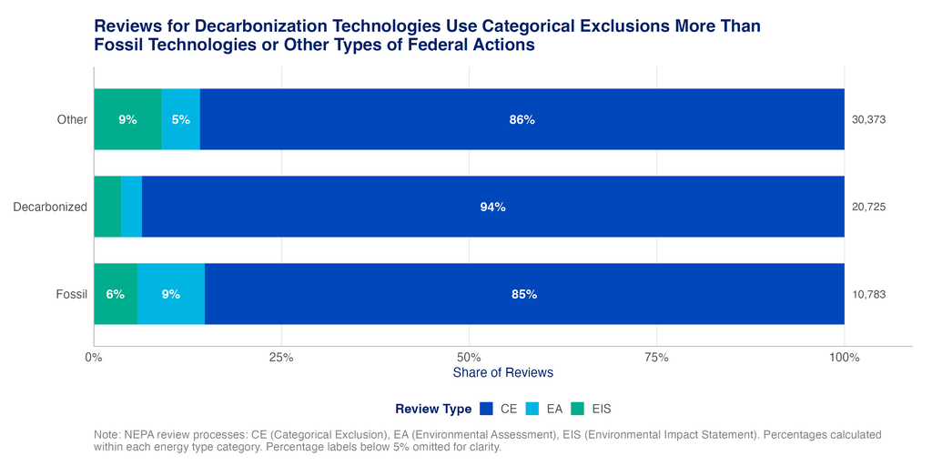

Figure 1: Note: NEPA process composition by energy classification. Decarbonization projects are more concentrated in Categorical Exclusions than fossil or other project types.

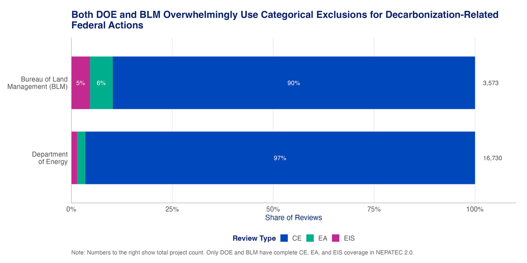

Figure 2: Note: NEPA process type distribution for departments with complete CE, EA, and EIS coverage in NEPATEC 2.0: DOE (all sub-agencies) and BLM. DOE shows overwhelming CE dominance; BLM has a more balanced mix.

### 1.3 Long NEPA review are not the main bottleneck for solar.

Within the current technology-tagged output, there are 2,483 solar actions total; 91.7% are CEs, 3.5% are EAs, and only 4.8% are EISs. Given that most solar-reviewed project are granted categorical exclusions, the NEPA review process is likely not the main bottleneck for most solar activity. Other constraints such as transmission access, interconnection, land availability, agency capacity, and financing may matter more than full-scale NEPA review.

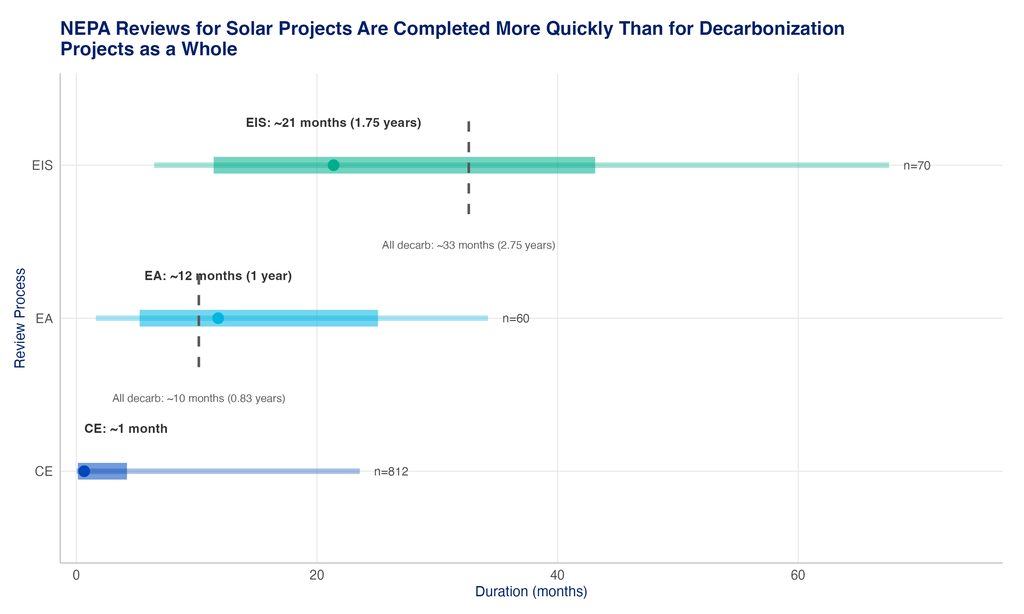

Figure 3: Note: Thin bar = p10 to p90, thick bar = IQR (p25 to p75), point = median.

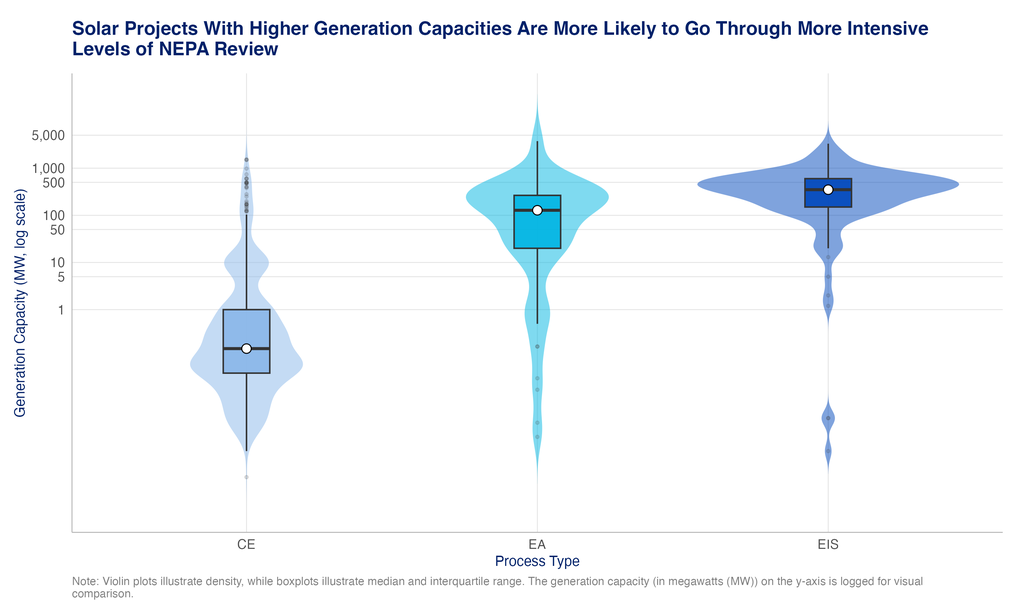

Figure 4: Note: Violin illustrate density, while boxplots illustrate median and interquartile range. The megawatt (MW) on the y-axis is logged for visual comparison.

# 2. There Are Real Efficiency Gains to Be Had in NEPA Implementation at the Agency Level

### 2.1 Programmatic and tiered reviews remain underutilized strategic tools

The evidence on programmatic and tiered reviews indicates that there are real efficiency gains from avoiding project-specific environmental impact statements. However, programmatic and tiered reviews are rare: only 161 of 1,326 decarbonization EA/EIS reviews (12.1%) are programmatic or tiered, indicating that there are opportunities for agencies to increase their use, as appropriate.

Tiered EAs take longer than standard EAs on average (734 versus 421 days), but have a substantially shorter timeline than a full EIS. This suggests the real efficiency gain from tiering is when it allows an agency to avoid a full EIS altogether rather than just shortening the timeline of an EA. Tiered EISs take less time than standard and programmatic EISs (though distributions substantially overlap and sample sizes are small).

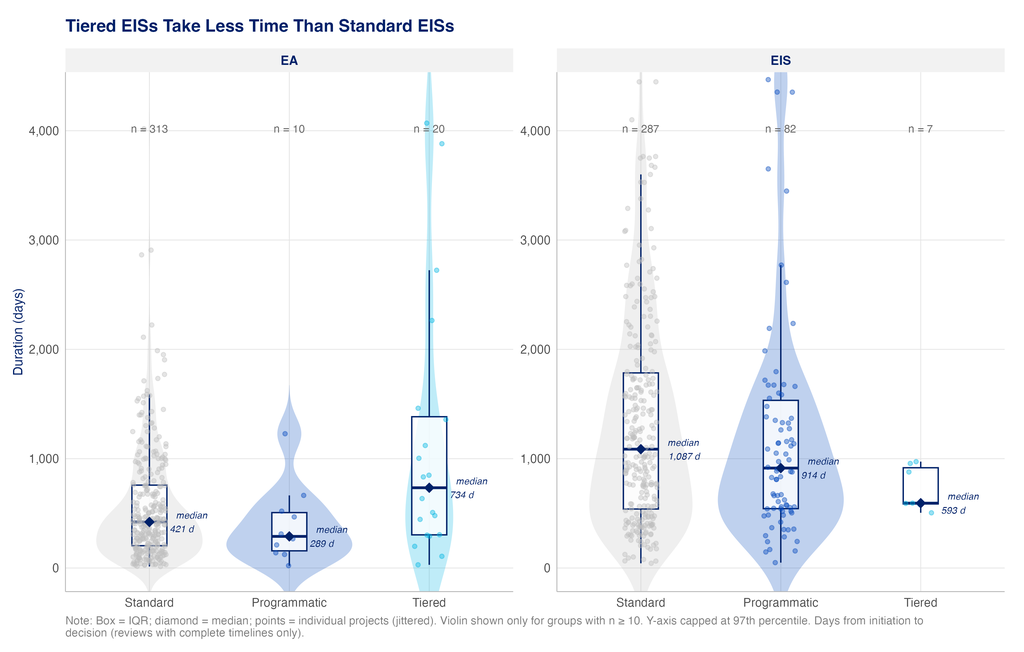

Figure 5: Note: Review duration by review type and NEPA process. Small sample sizes mean the results should be treated as directional, not definitive.

### 2.2 Increased interagency coordination could meaningfully impact efficiency gains

[Previous CATF research](https://www.catf.us/resource/evidence-based-recommendations-overcoming-barriers-federal-transmission-permitting/) on transmission permitting has demonstrated that insufficient support for agency coordination, cooperation, and capacity contributes to longer permitting timelines. This research builds on that finding by mapping which agencies collaborate the most on NEPA reviews. Using parsed co-agency names from review documents, the strongest collaboration hubs are concentrated in DOE, DOI, DOD, EPA, and USDA. Department of the Interior ranks highest by bridge score (64.2), while Department of the Interior carries the largest number of collaborative project ties (209). That suggests that targeted staffing, memoranda of understanding, and other coordination mechanisms should focus on the recurring federal partner network rather than only the formal lead agency.

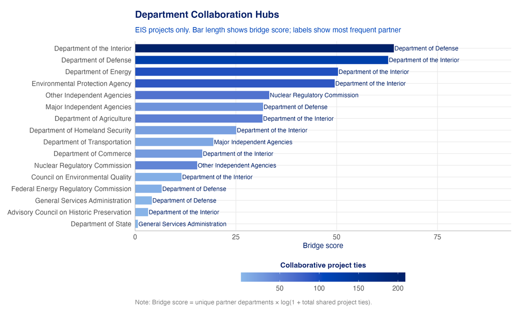

Figure 6: Note: Federal departments ranked by bridge score using parsed co-agency relationships. Bar length shows bridge score and label shows most frequent partner.

The flow diagram below offers a complementary view of the same pattern for EIS projects. Each band flows from the lead or responsible department to a cooperating or participating partner department, with width proportional to the number of shared project ties. The network is concentrated among a small group of repeat partners, but the direction makes clear whether a department is primarily leading reviews, partnering on reviews, or doing both.

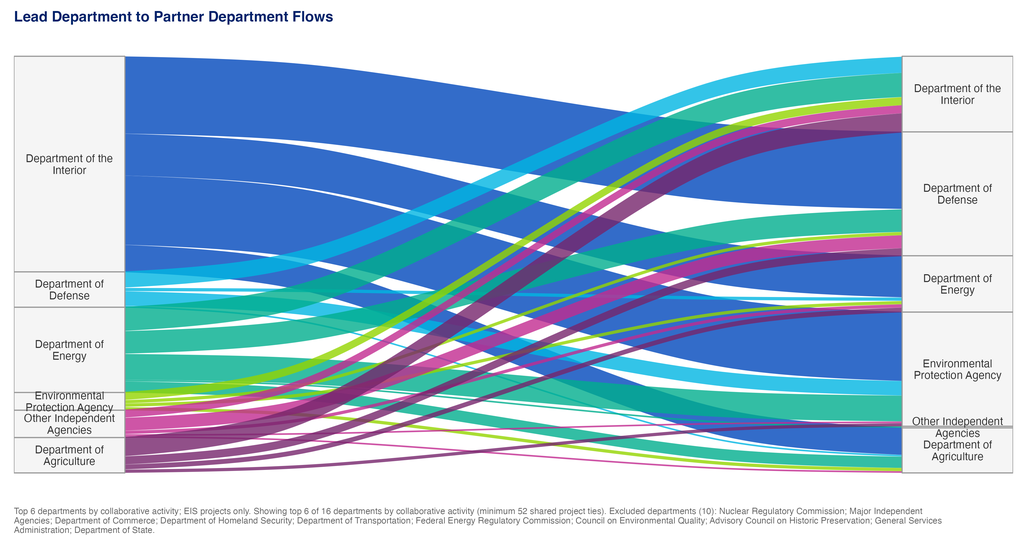

Figure 7: Note: Cross-department project flows for the top six departments by collaborative activity. Flow width reflects the number of shared project ties.

# 3. Permitting Reforms in the Fiscal Responsibility Act of 2023 Have Had a Real, but Modest, Impact

The [Fiscal Responsibility Act of 2023 (Public Law 118-5)](https://ceq.doe.gov/laws-regulations/fra.html) introduced page limits for NEPA environmental reviews. Under the law, environmental assessments must be 75 pages or less and environmental impact statements must be either 150 pages or less, or for proposals of extraordinary complexity, under 300 pages or less.

There is considerable variation in average page length of documents over time. Using a 3-month rolling average, we see a slight decline in average page length after FRA’s passage, but a return to pre-FRA rates more recently. To some extent, this is likely a result of a small sample size post-FRA: only 33 EAs and 42 EISs.

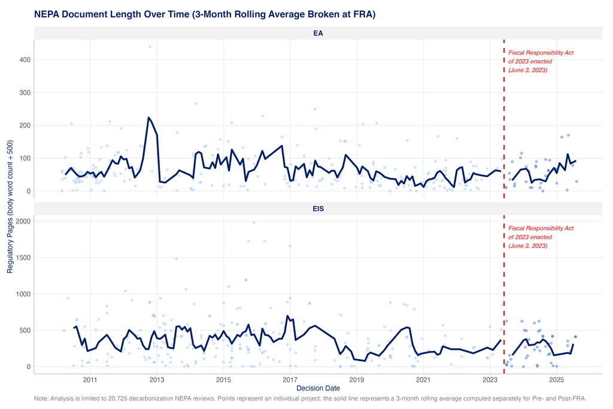

Figure 8: Note: Points represent individual projects (colored by FRA period); the solid line represents a 3-month rolling average computed separately for Pre- and Post-FRA.

Viewed another way, our analysis shows a real but modest post-FRA shift in document length pre- and post-FRA. Average and median regulatory page counts mostly decline after the FRA threshold, which is consistent with agencies responding to the new statutory limits.

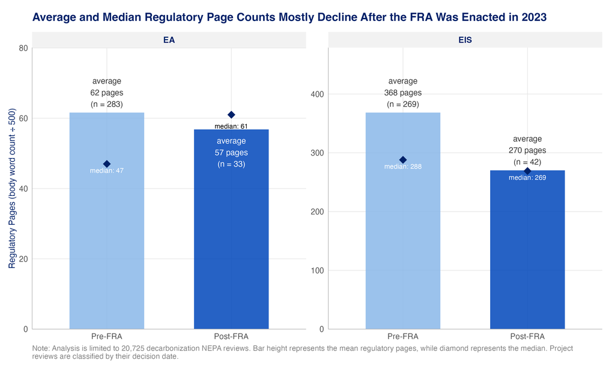

Figure 9: Note: Bar height represents the mean regulatory pages, while diamond represents the median. Project reviews are classified by their decision date.

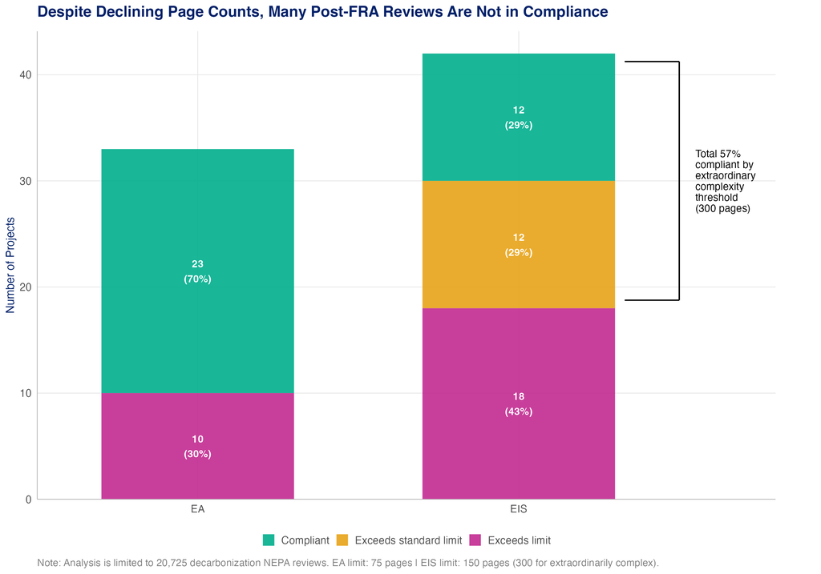

Figure 10: Note: EA limit: 75 pages | EIS limit: 150 pages (300 for extraordinarily complex).

# Caveats and Considerations

Several considerations from the fact sheet should remain front-of-mind when translating these findings into policy recommendations.

**Data quality and completeness remain a structural limitation.**

- NEPATEC 2.0 assembles documents from multiple sources: EIS records are drawn from EPA’s governmentwide EIS database and are broadly representative since 2012, but EA and CE data are substantially complete only for DOE and BLM. This means the dataset captures a large share of the federal decarbonization NEPA universe but not all of it — for example, coverage is thin for agencies like the Corps of Engineers or the Forest Service.
- Better federal metadata standards, document-linkage practices, and centralized submission requirements would improve nearly every downstream permitting analysis. One coveted data point would be project timeline data. In its current form, all timeline data was extracted directly from document text: this is an inefficient, unwieldy, and somewhat inaccurate process. Future iterations of the NEPATEC database would benefit greatly from including this as metadata, likely requiring NEPA reviewers to provide a summary of key dates within all NEPA documents.
- Existing efforts such as PermitAI, CEQ’s NEPA data standard, and the ePermit Act move in the right direction, but they do not yet solve the broader fragmentation problem — and significant additional investment in federal data infrastructure is still needed.

**High CE usage is not automatically a normative success — using CEs to move projects through NEPA faster, rather than because they genuinely qualify, warrants scrutiny.**

- Categorical Exclusions are a legitimate and appropriate tool when applied within statutory bounds: they are designed for classes of actions that experience has shown to have no significant individual or cumulative environmental effects. Their integrity depends on applying the right tool to the right action. When CEs are used primarily to compress timelines rather than because an action genuinely fits an established exclusion, the core purpose of the process is undermined. The goal of NEPA should not be faster approvals but more efficient reviews that ensure each project or action receives the appropriate level of scrutiny. A CE that shortens a timeline by bypassing warranted analysis trades short-term speed for downstream litigation risk and larger-than-expected environmental impact. These concerns are not directly observable in NEPATEC — the dataset captures the formal record, not the quality of the underlying analysis. A count of CEs is not the same as an assessment of the quality of a CE determination.

**Faster timelines are not the only policy goal, and speed can come at the cost of quality and legal durability.**

- Review quality, agency learning, and public legitimacy matter alongside speed. DOI’s recent production of EISs in as little as two weeks is a salient example: a document of that scope produced on that timeline raises serious questions about whether meaningful analysis took place, regardless of what the formal record shows. Rushing NEPA reviews may trade short-term permitting speed for downstream litigation risk and larger-than-expected environmental impact — the opposite of what well-designed reform should produce.

**Some of the most important questions remain outside of the scope of work for this first phase.**

- In particular, the present work does not directly test whether NEPA was the actual cause of project delay, what were the main triggers of NEPA review, nor does it comprehensively analyze when agencies may have relied on CEs too aggressively.

# Appendix: Scope of Analysis

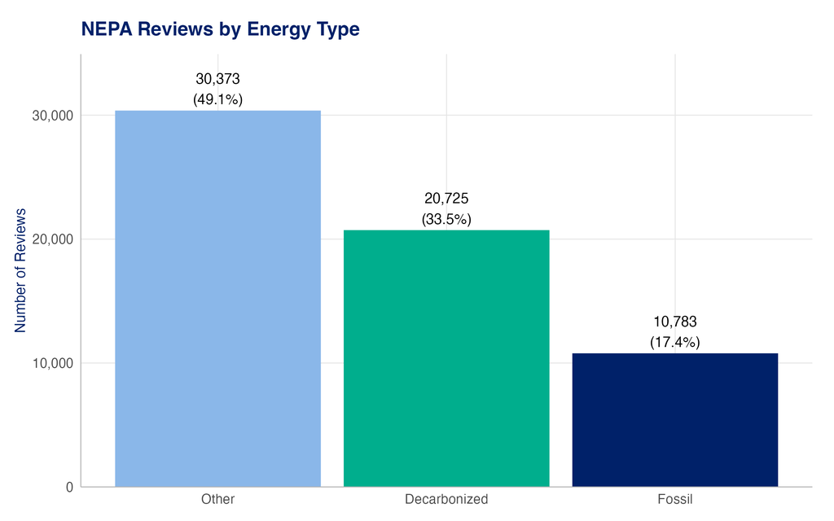

Figure 11: Note: NEPA reviews by energy type. Decarbonization technologies account for roughly one-third of all reviews in the database.